# 빅데이터시각화_08장

Lee Jun Haeng

2021 11 23

# 08. 유용한 그래픽스와 시각화 분석

### 08.1 한 그림에 두 개의 y축 사용하기

##### 예제1

1974~1979년 영국에서 발생한 여성과 남성의 폐질환으로 인한 사망자 수를 나타내는 시게열 자료를 비교한다.  
이 자료는 남성 사망자가 더 큰 빈도를 보이는 자료이다.

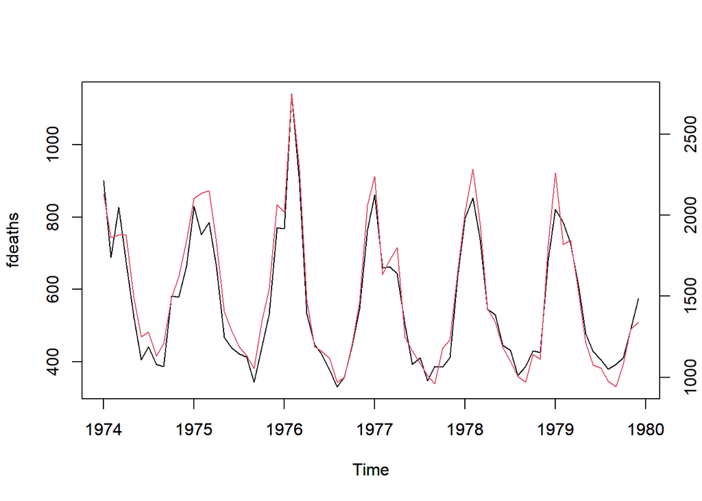

```r
## fdeaths, mdeaths, ldeaths는 각각 여성, 남성, 전체 사망자를 나타내는 시계열 객체임
plot(fdeaths)
par(new=TRUE)
plot(mdeaths, yaxt="n", ylab="", col=2)
axis(4)
mtext("mdeaths", side=4, line=3)
```

##### 예제2

정규분포로부터의 난수 자료를 이용하여, 스케일이 다른 자료에 대한 다양한 그림을 그리는 방법을 제시한다.

```r
library(latticeExtra)
```

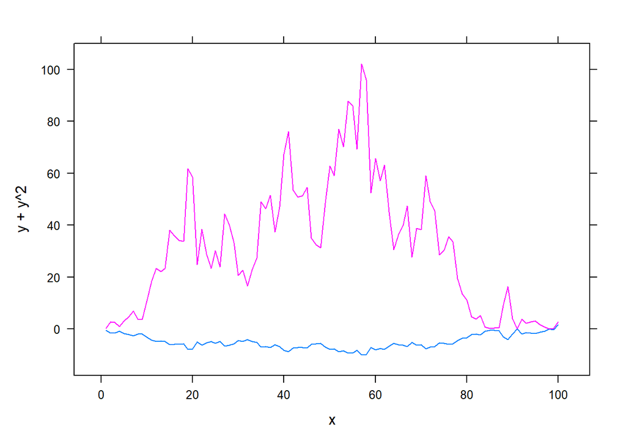

```r
library(lattice)
set.seed(1000)
foo <- list(x=1:100, y=cumsum(rnorm(100)))

## 원 자료 그림
xyplot(y+y^2 ~ x, foo, type="l")
```

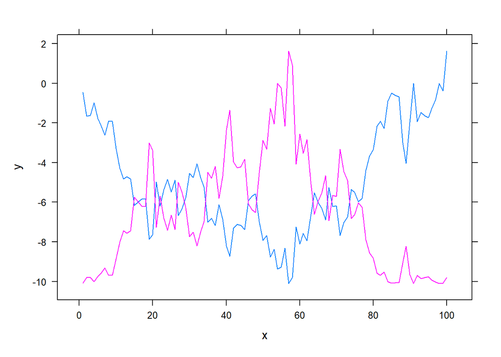

```r
## 각 계열에 대해 분리된 그림
obj1 <- xyplot(y ~ x, foo, type="l")
obj2 <- xyplot(y^2 ~ x, foo, type="l")

## 단순한 경우 : 중복되는 그림의 y축 값을 표시하지 않음
doubleYScale(obj1, obj2, add.axis=FALSE)
```

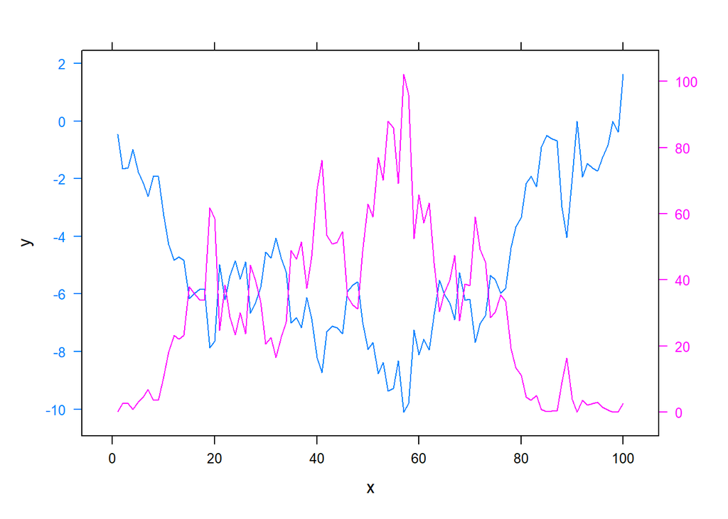

```r
## 축을 표시함
doubleYScale(obj1, obj2)
```

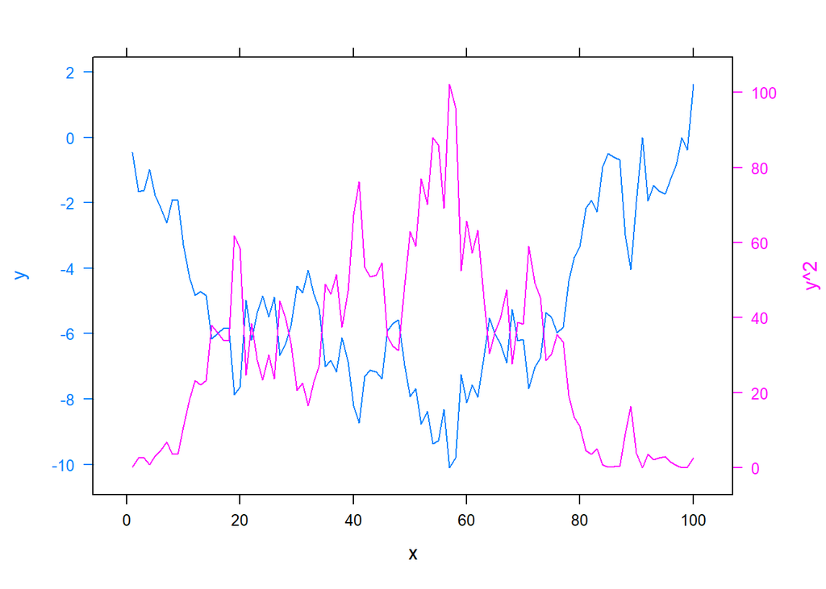

```r
## y 라벨 추가
doubleYScale(obj1, obj2, add.ylab2=TRUE)
```

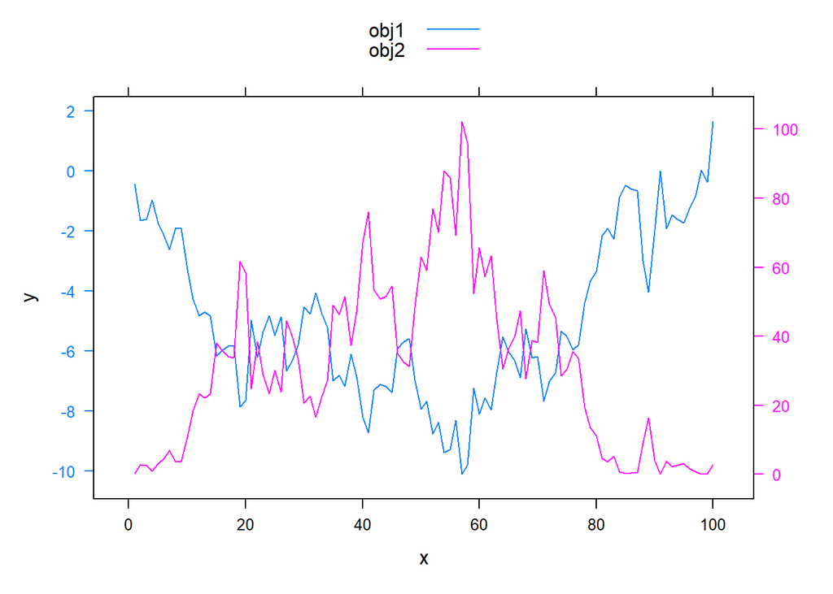

```r
## 키(key)를 추가: 그림 상단
doubleYScale(obj1, obj2, text=c("obj1","obj2"))
```

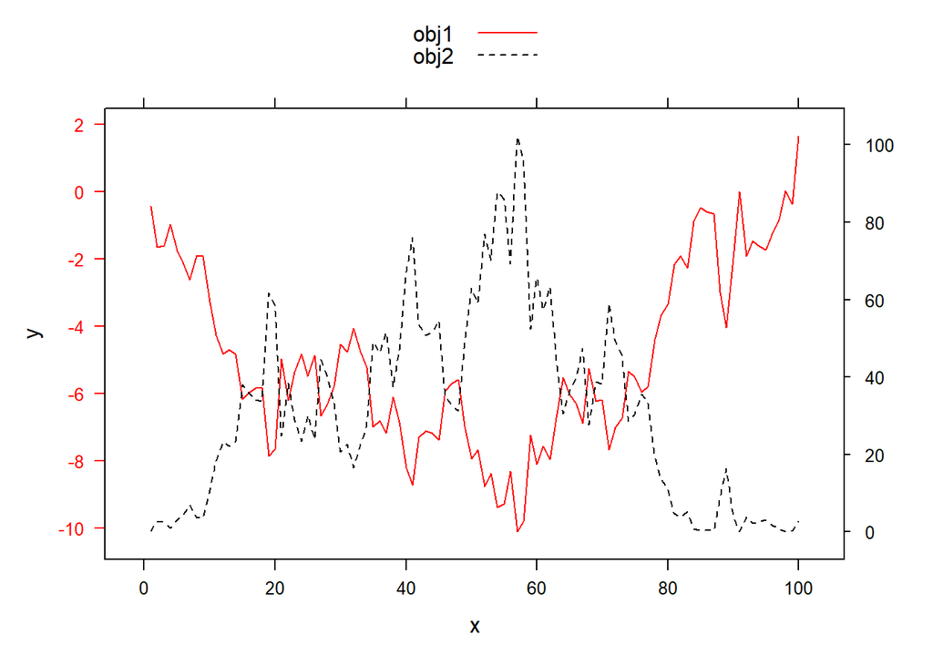

```r
## 맞춤형 그림
update(doubleYScale(obj1, obj2, text=c("obj1","obj2")),
       par.settings=simpleTheme(col=c('red','black'), lty=1:2))
```

##### 예제3

2007년 1월~3월 기간 동안 시에틀-타코마 공항의 일일 강우량과 기온 자료를 시각적으로 비교한다.

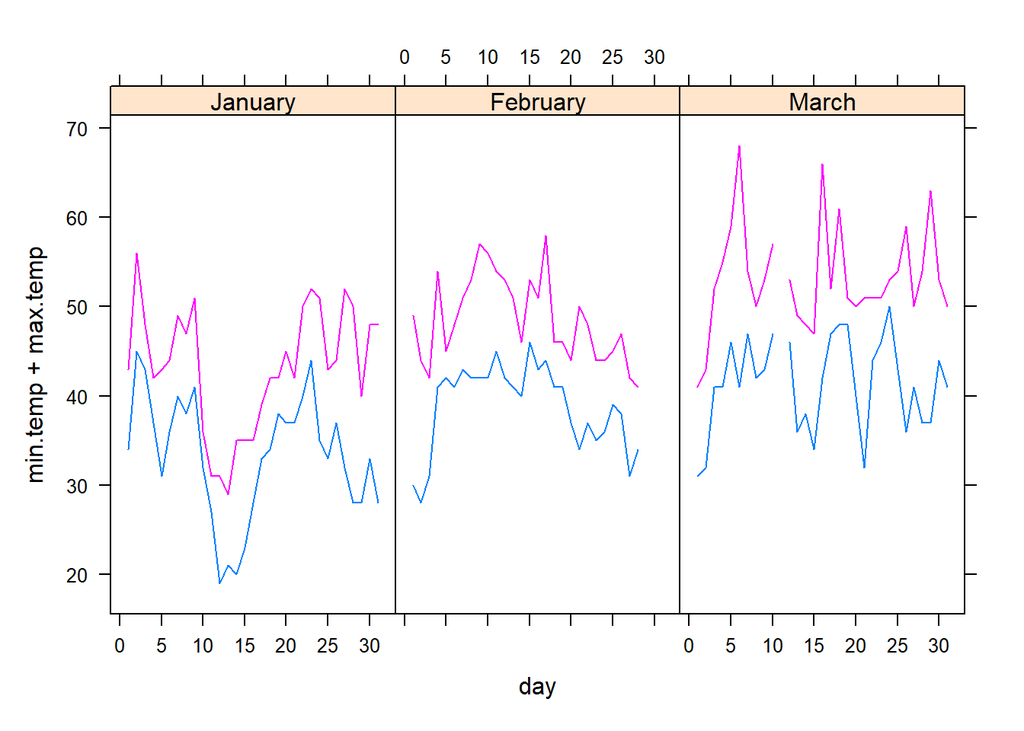

```r
data(SeatacWeather)
xyplot(min.temp + max.temp ~ day | month,
       data=SeatacWeather, type="l", layout=c(3,1))
```

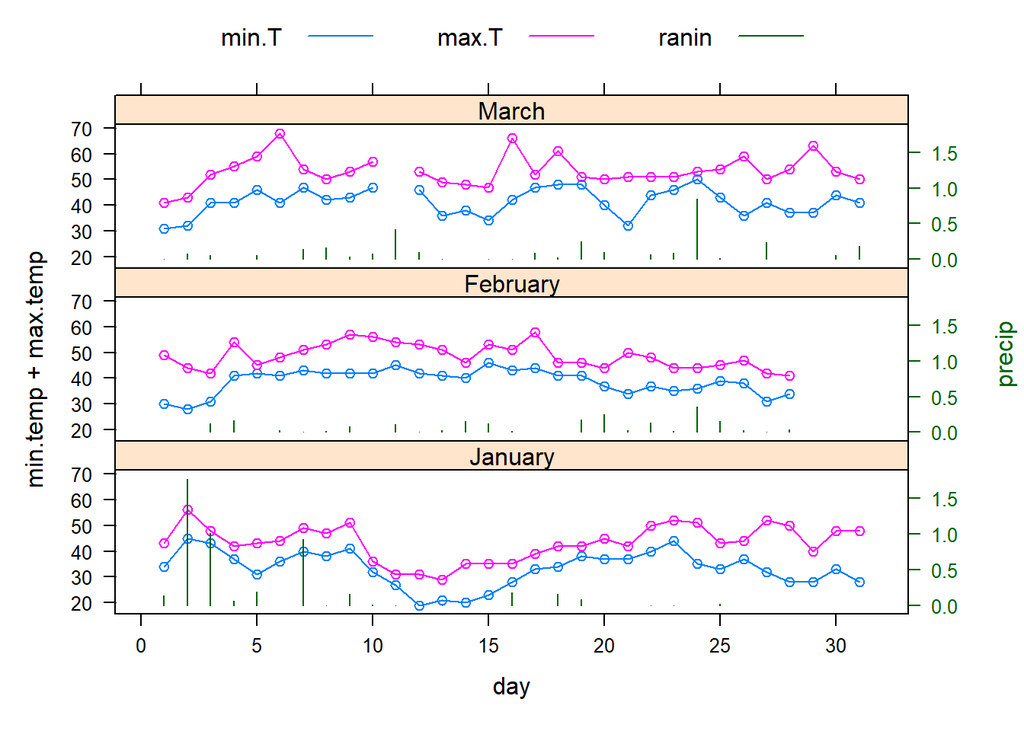

```r
temp <- xyplot(min.temp + max.temp ~ day | month,
       data=SeatacWeather, type="b", layout=c(1,3))
rain <- xyplot(precip ~ day | month, data=SeatacWeather, type="h")
doubleYScale(temp, rain,
             style1=0, style2=3,  #style1=, style2=옵션은 0(default) ~ 6의 값을 취함
             add.ylab2=TRUE,
             text=c("min.T", "max.T", "ranin"),
             columns=3)  # columns= 옵션은 text= 옵션의 형식을 지정
```

##### 예제4

히스토그램과 밀도함수 추정곡선을 함께 그린다.  
두 그림은 서로 다른 스케일을 가지는 그림으로 하나의 그림에 두 개의 y축이 사용되었다.

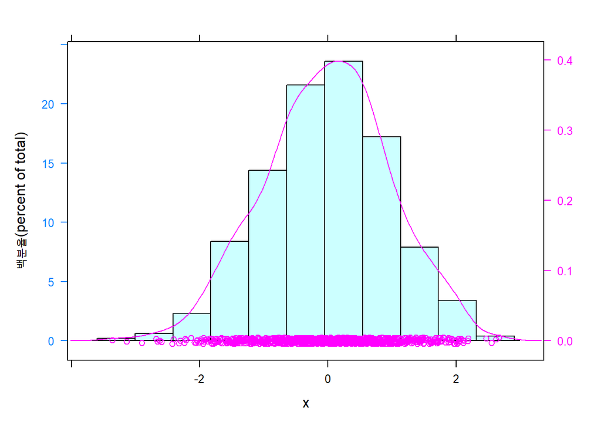

```r
library(latticeExtra)
library(lattice)
set.seed(1000)
x <- rnorm(1000)
doubleYScale(histogram(x), densityplot(x), use.style=TRUE)
```

```r
## use.style=TRUE는 각 함수의 적용 결과를 색으로 구분해 줌
```

### 08.2 스케일이 다른 그림 겹쳐 그리기

as.layer{latticeExtra} 함수는 x축과 y축(또는 두 축 모두)의 스케일(scale)이 동일하거나 다른 스케일 상에 그려진 격자플롯을 겹쳐 그리거나, 한개의 패널 layer를 다른 객체의 여러 개의 패널에 적용한 그림을 그려준다.

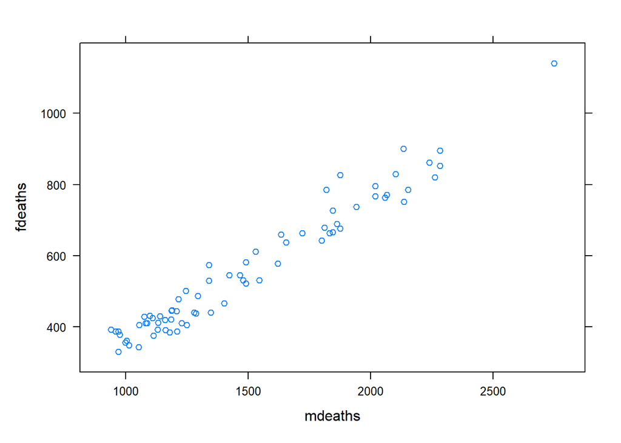

```r
## 예제 : 폐질환 사망자수 자료(fdeaths, mdeaths, ldeaths) 이용
xyplot(fdeaths ~ mdeaths)
```

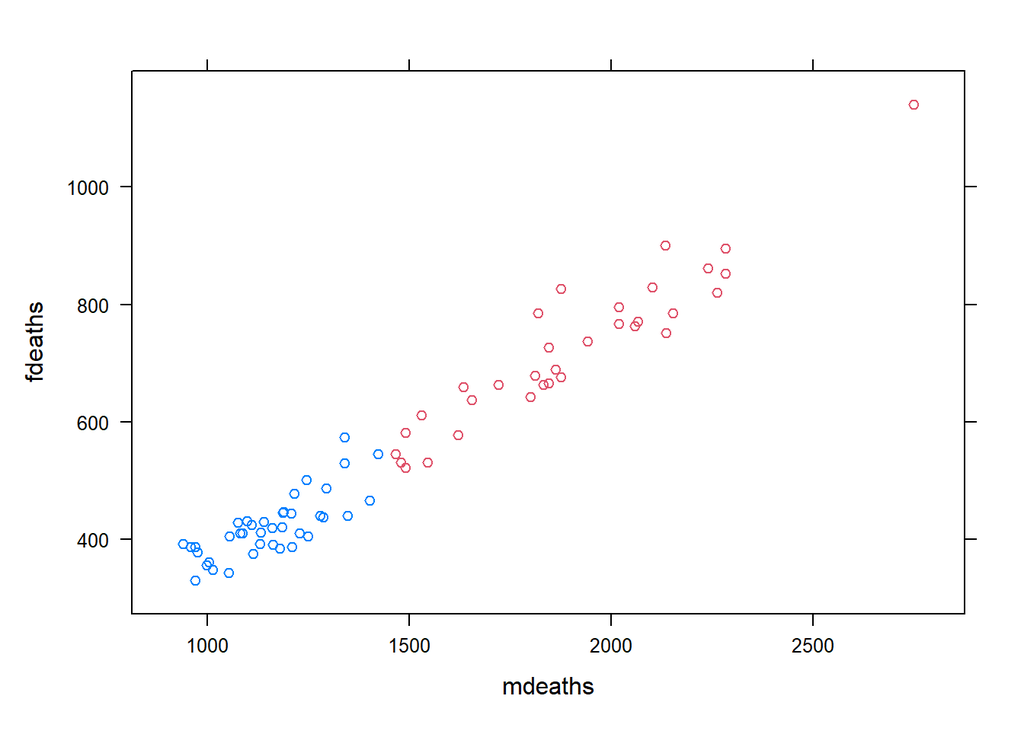

```r
## x, y의 스케일이 동일한 경우(디폴트)
xyplot(fdeaths ~ mdeaths) +
  as.layer(xyplot(fdeaths ~ mdeaths, col=2, subset=ldeaths > 2000) )
```

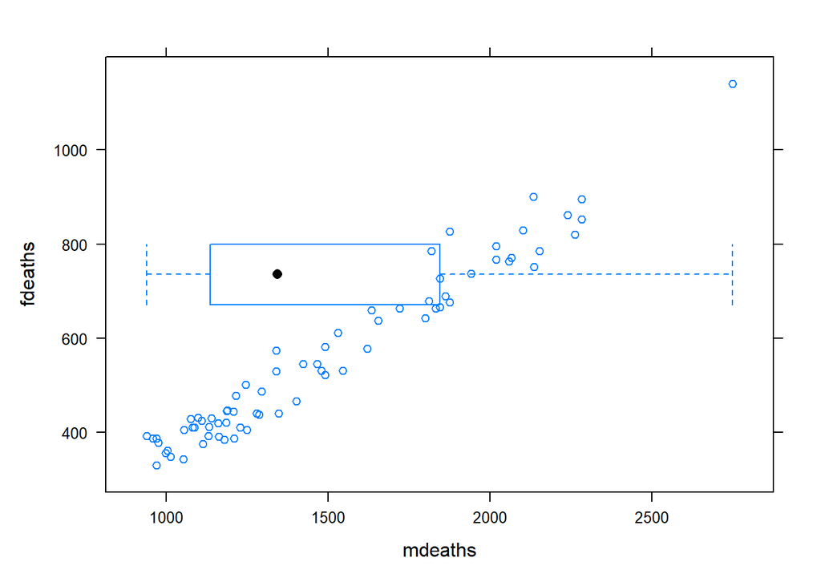

```r
## x 스케일은 동일하나, y 스케일이 다른 경우
xyplot(fdeaths ~ mdeaths) +
  as.layer(bwplot(~ mdeaths, box.ratio=0.2), y.same=FALSE)
```

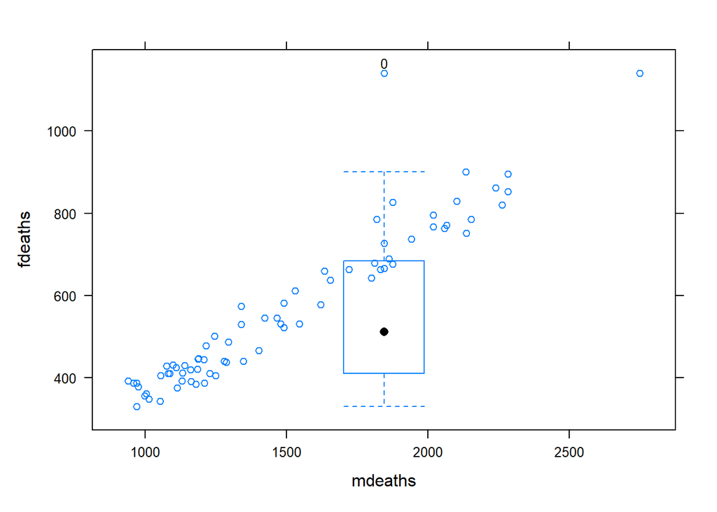

```r
## box.ratio= 옵션은 상자의 폭을 지정함

xyplot(fdeaths ~ mdeaths) +
  as.layer(bwplot(fdeaths ~ factor(mdeaths*0), box.ratio=0.2), x.same=FALSE)
```

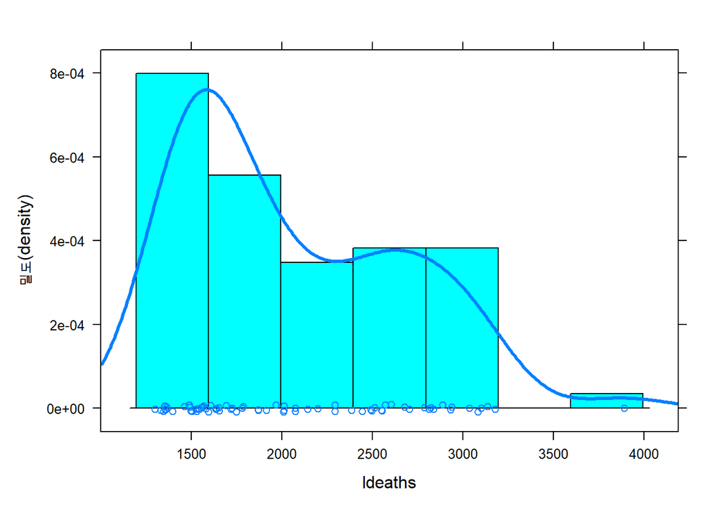

```r
## 두 개의 플롯이 더해지면 as.layer() 함수가 자동으로 호출됨
histogram(~ ldeaths, type="density") + densityplot(~ ldeaths, lwd=3)
```

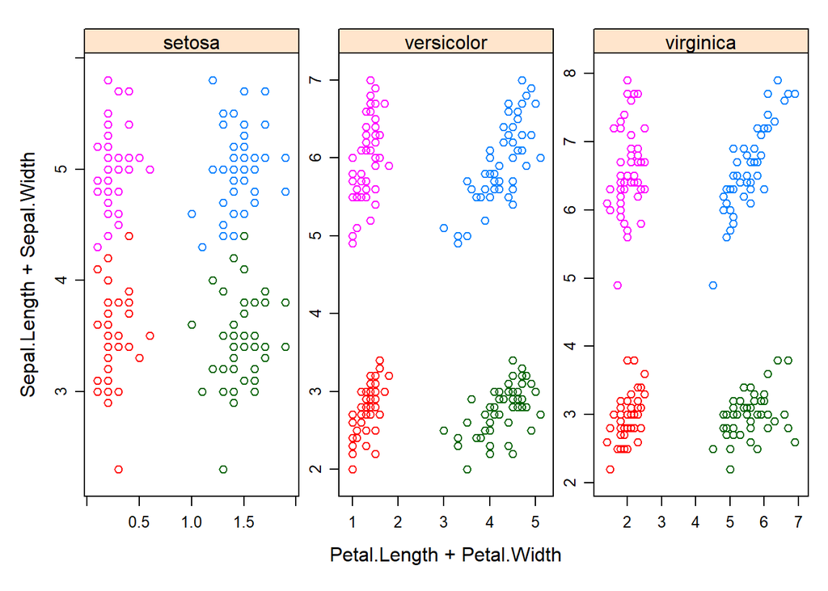

```r
## 하나의 패널 layer를 다른 객체의 여러 개 패널 layer에 적용함
xyplot(Sepal.Length + Sepal.Width ~ Petal.Length + Petal.Width | Species,
       data=iris, scales="free")
```

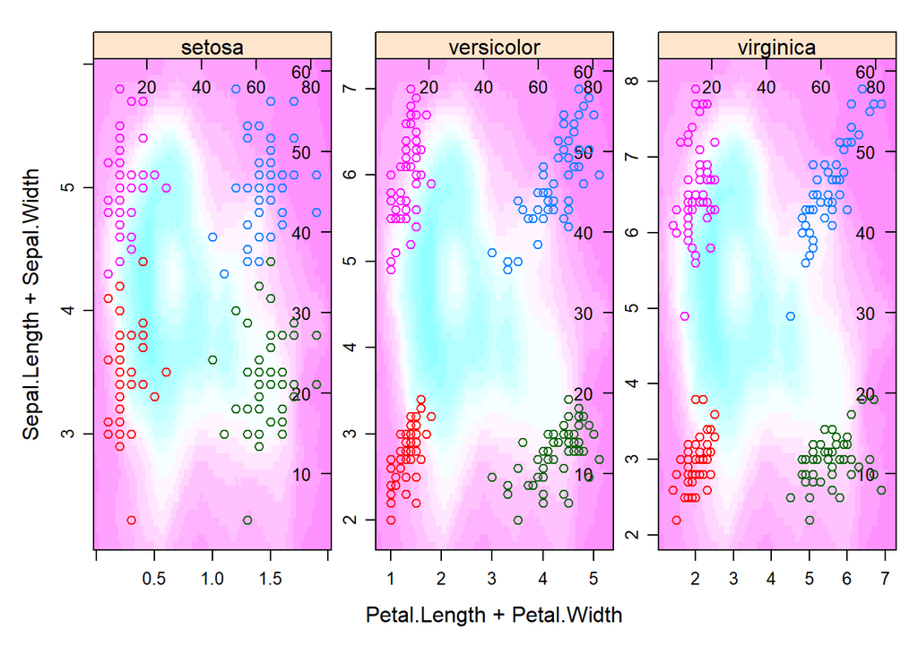

```r
xyplot(Sepal.Length + Sepal.Width ~ Petal.Length + Petal.Width | Species,
       data=iris, scales="free") +
  as.layer(levelplot(volcano), x.same=FALSE, y.same=FALSE, under=TRUE)
```

### 08.3 {openair} 패키지를 활용한 시각화 1

#### 08.3_1 {openair} 패키지를 활용한 시계열 자료의 시각화

{openair}는 다양하고 편리한 시각화 기능을 제공한다.  
여기서는 데이터프레임 구조로 저장된 시계열 자료의 시각화를 소개한다.

```r
library(openair)
data(mydata)
str(mydata)
```

```
## tibble [65,533 x 10] (S3: tbl_df/tbl/data.frame)
##  $ date: POSIXct[1:65533], format: "1998-01-01 00:00:00" "1998-01-01 01:00:00" ...
##  $ ws  : num [1:65533] 0.6 2.16 2.76 2.16 2.4 3 3 3 3.36 3.96 ...
##  $ wd  : int [1:65533] 280 230 190 170 180 190 140 170 170 170 ...
##  $ nox : int [1:65533] 285 NA NA 493 468 264 171 195 137 113 ...
##  $ no2 : int [1:65533] 39 NA NA 52 78 42 38 51 42 39 ...
##  $ o3  : int [1:65533] 1 NA 3 3 2 0 0 0 1 2 ...
##  $ pm10: int [1:65533] 29 37 34 35 34 16 11 12 12 12 ...
##  $ so2 : num [1:65533] 4.72 NA 6.83 7.66 8.07 ...
##  $ co  : num [1:65533] 3.37 NA 9.6 10.22 8.91 ...
##  $ pm25: int [1:65533] NA NA NA NA NA NA NA NA NA NA ...
```

[output not shown]

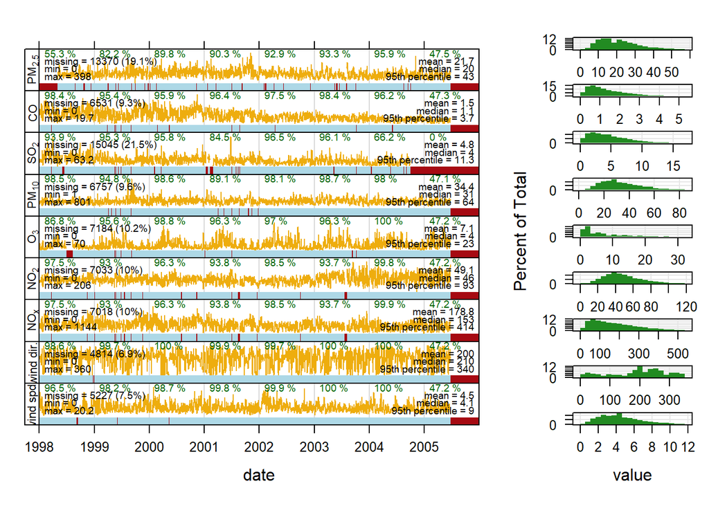

```r
summaryPlot(mydata)
```

##### 예제5

timePlot() 함수의 적용 예 : mydata 이용

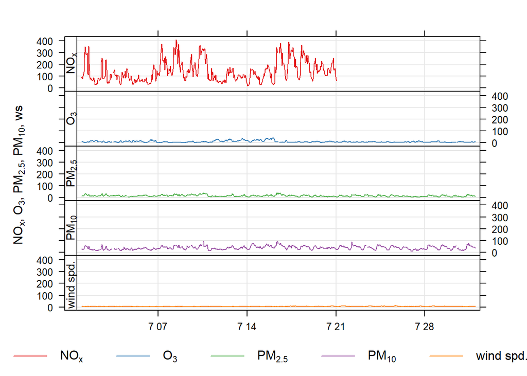

```r
timePlot(selectByDate(mydata, year=2003, month=7),
         pollutant=c("nox","o3","pm25","pm10","ws"))
```

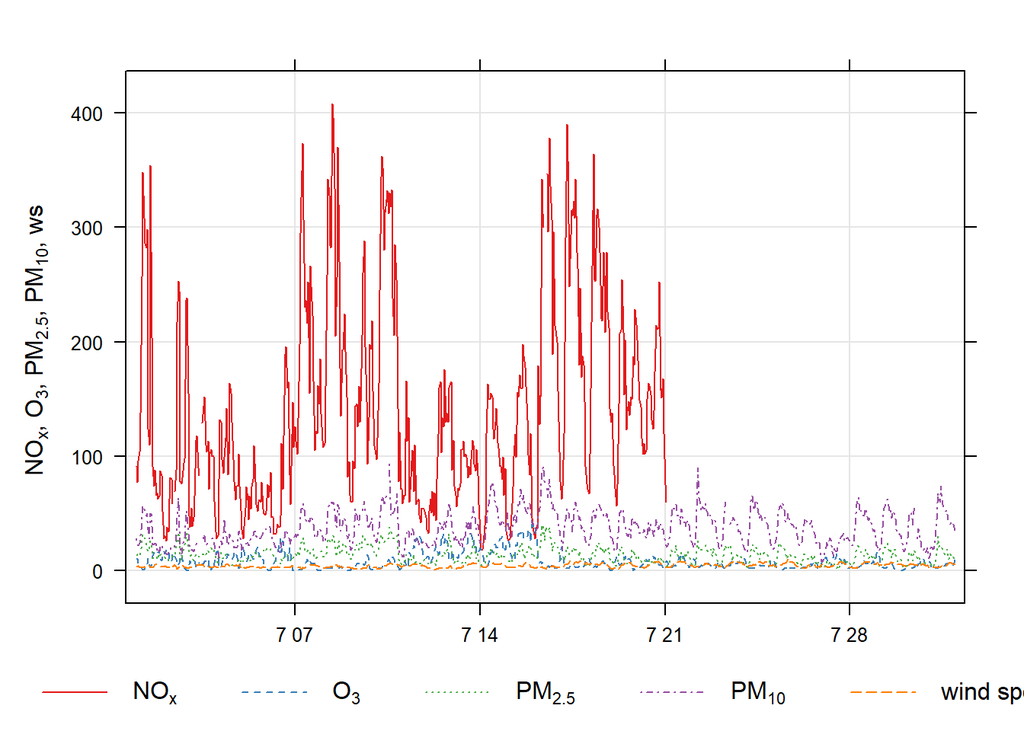

```r
## group=TRUE 옵션 추가시
timePlot(selectByDate(mydata, year=2003, month=7),
         pollutant=c("nox","o3","pm25","pm10","ws"),
         group=TRUE)
```

selectByDate{openair} 함수는 날짜에 기초한 데이터프레임의 부분 집합을 생성한다.  
이 함수의 일반 용법과 옵션은 다음과 같다.

```r
selectByDate(mydata, start="1/1/2008", end="31/12/2008",
             year=2008, month=1, day="weekday", hour=1)
```

```
## # A tibble: 0 x 10
## # ... with 10 variables: date <dttm>, ws <dbl>, wd <int>, nox <int>, no2 <int>,
## #   o3 <int>, pm10 <int>, so2 <dbl>, co <dbl>, pm25 <int>
```

[output not shown]

#### 08.3_2 {openair} 패키지의 기타 시각화 함수

#### 08.3_3 날짜-시간 변환 함수

### 08.4 {openair} 패키지를 활용한 시각화 2

##### (c) plot(format()) 함수를 이용한 시각화

##### (d) 기타 유용한 {openair} 함수